[figure not shown]

WI-453

Rear Wiring Harness RH

WIRING SYSTEM

70.Rear Wiring Harness RH

A: LOCATION

Connector Connecting to

No. Pole Color Area No. Description

AB18 15 Y C-3 Airbag CM

AB24 4 Y B-3 Side airbag module RH

AB26 2 B B-3 Pretensioner RH

AB28 4 Y B-3 Side airbag sensor RH

AB30 2 B B-3 Lap seat belt pretensioner RH

AB53 3 GR B-3 AB59 Occupant detection wiring harness

AB59 3 BR B-3 AB53 Rear wiring harness

AB60 2 Y B-3 Buckle switch

AB61 10 B C-3 Occupant detection control module

AD6 20 D-5 R34 Airbag wiring harness

AD7 6 D-4 AUX input terminal

AD8 8 D-4 Seat heater switch

AD9 2 D-4 Rear accessory power supply socket (console)

AD10 10 D-4 R33 Rear wiring harness LH

R1 20 C-1 B97 Bulkhead wiring harness

R12 3 A-3 Front door switch RH

R13 8 A-3 D28 Rear door cord RH

R21 12 B B-4 R18 Rear wiring harness RH

R33 10 D-4 AD10 Multi select switch

R34 20 D-5 AD6 Adapter cord LH

R42 4 B-4 Seat heater switch RH

R43 4 L B-4 Seat heater switch LH (without SI-DRIVE)

R44 4 B-3 Seat heater RH

R82 19 B B-4 R81 Rear wiring harness LH

R98 24 C-1 i53 Instrument panel wiring harness

R124 2 C-1 AB63 Airbag wiring harness

R284 6 B-5 AUX input terminal

R311 2 B-5 Rear accessory power supply socket (console)

R382 20 C-1 i195 Instrument panel wiring harness

: White or natural color

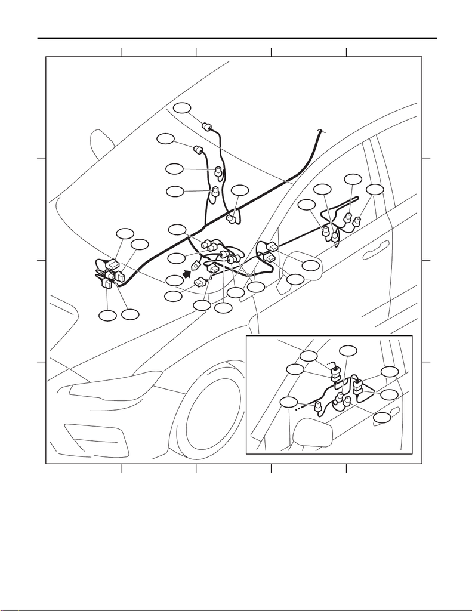

WI-454

Rear Wiring Harness RH

WIRING SYSTEM

WI-44625

12345

12345

A

B

C

D

A

B

C

D

ENGINE TYPE EJ

GB-13

AB26

AB30

AB28

R12

R13

AB24

R44

R98

R382

R1

R124

AB61

AB18

AB59

AB60

AB53

AD9

AD8

AD7

AD10

R33

AD6

R34

R82

R21

R42

R43

R311

R284